# Bariogénesis en modelos de multipletes de $SU(2)_{L}$

Contexto y definiciones

Jovanny Jara

28/5/2026

## Definiciones

### Asimetría bariónica del universo

- Mejor conocida como el *problema de la asimetría materia-antimateria*, una pregunta fundamental sin resolver en cosmología y física de partículas.
- Observaciones cosmológicas indican que el universo está compuesto principalmente por materia, con una cantidad insignificante de antimateria.
- Se espera que el Big Bang haya producido cantidades iguales de materia y antimateria, lo que no se observa en la actualidad.
- Existen varias hipótesis para explicar el proceso que llevó a la **bariogénesis**, el mecanismo que generaría la asimetría bariónica.

### Condiciones para la bariogénesis

Conocidas como las *condiciones de Sakharov* y propuestas por el físico soviético Andrei Sakharov en 1967, son tres requisitos fundamentales para que ocurra la bariogénesis:

1. **Violación de la simetría bariónica**: Debe existir un proceso que viole la conservación del número bariónico, permitiendo la creación o destrucción de bariones.
2. **Violación de la simetría C y CP**: Debe haber procesos que violen la simetría de carga (C) y la combinación de carga y paridad (CP), lo que permite que las reacciones no sean idénticas para materia y antimateria.
3. **Desacoplamiento térmico**: Las interacciones que violan el número bariónico deben ocurrir fuera del equilibrio térmico, lo que permite que la asimetría se mantenga a medida que el universo se expande y enfría.

### Esfalerones

- Solución estática a las ecuaciones de campo electrodébil.
- Es un punto silla, que puede caer a dos estados estables con distinto número bariónico; uno con tres bariones o uno con 3 anti-leptones. Dichos estados pueden transicionar de dos formas, puede tunelear en un proceso instantónico o ser llevados a energias altas de forma que pueda cruzar la barrera clásicamente en un proceso esfalerónico.

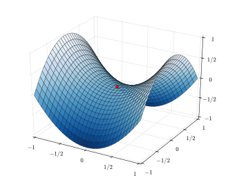